# Estatística Descritiva

Análise de Dados I - 2018.1

## Probabilidade vs. Estatística

- A **probabilidade** buscar prever a chance de eventos futuros ocorrerem
  - A **estatística** analisa a frequência de eventos passados
- A **probabilidade** é um ramo da matemática teórica sobre consequências de definições
- A **estatística** é matemática aplicada na busca de entender observações do mundo real

## Distribuições de variáveis aleatórias

- Variáveis Aleatórias (VAs) são funções numéricas onde valores possuem probabilidades
- A função densidade de probabilidade (*FDP*) mostra VAs (como histogramas)

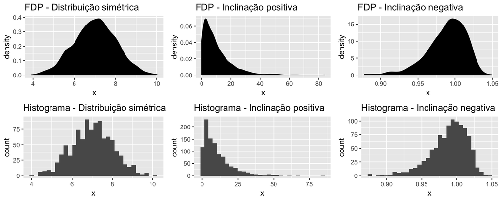

## Distribuições de variáveis aleatórias

- Função Densidade Acumulada (FDA) é o somatório da FDP
  - FDA é a integral da FDP, enquanto a FDP é a derivada da FDA

\[C(X \leq k) = \sum_{x \leq k} P(X = x)\]

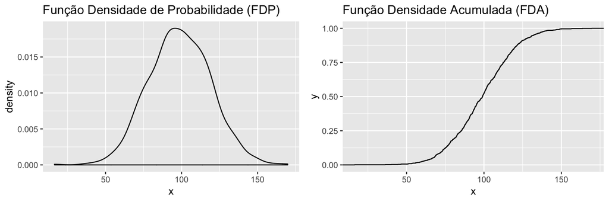

## Visualizando distribuições acumuladas

- As vendas de iPhone estão bombando?

[figure not shown]

## O crescimento é mesmo significativo?

- Distribuições acumuladas podem dar uma visão errônea do crescimento
  - A mudança incremental é a derivada da FDA, que é difícil de visualizar

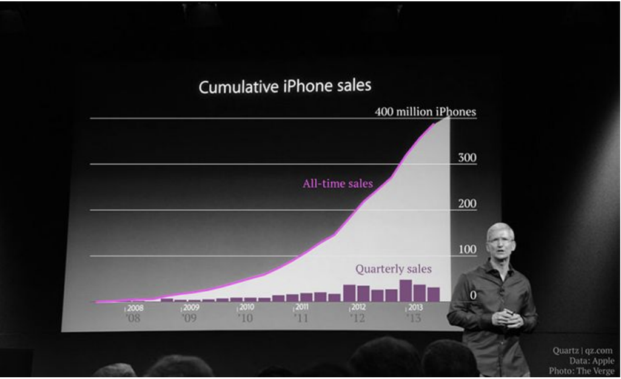

## Estatística descritiva vs. inferencial

- **Estatística descritiva**: captura as propriedades e distribuição dos dados
  - *Medidas de tendência central* descrevem o centro de sua distribuição
  - *Medidas de variabilidade ou dispersão* descrevem o seu espalhamento
- **Estatística inferencial**: para tomar decisões e achar relações nos dados
  - Usa fundamentos e teorias da probabilidade
  - Preocupa-se em modelar fenômenos aleatórios
  - Exemplo: as diferenças nos dados entre duas situações podem ser atribuídas a diferenças reais ou ao acaso?

## Estatística descritiva

Objetivos:

- Dar uma noção de como os dados estão distribuídos
- Entender melhor a natureza dos dados
- Identificar pontos anormais (possíveis outliers)
- Apresentação gráfica de aspectos importantes dos dados
- Identificar relações entre variáveis

## Sumarização de dados: medidas de centralidade

## Medidas de centralidade com número único

- Um número que seja representativo da maior parte dos dados
- Índices de tendência central (*average*) mais populares:
  - Média amostral
  - Mediana amostral
  - Moda amostral

## Medida de centralidade: média aritmética

- Soma dos valores \(x\) dividido pelo número de observações \(n\):

\[\mu_x = \frac{\sum_{i = 1}^{n} x_i}{n}\]

- Também chamado de primeiro momento da distribuição ou valor esperado
- A média é significativa para distribuições simétricas
  - Mas é sensível *outliers*, principalmente se a amostra é pequena

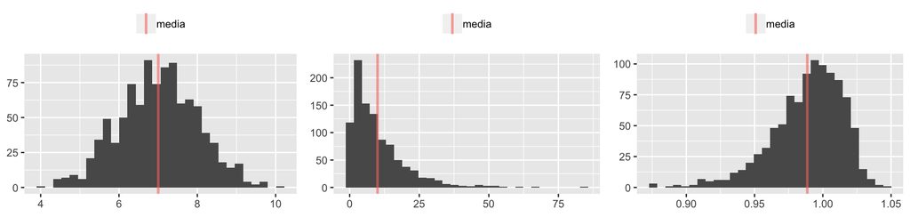

## Medida de centralidade: mediana

- A mediana é o valor que divide os dados no meio (50-percentil ou 0.5-quantil)
  - Metade da massa de probabilidade está de um lado e de outro
  - É mais resistente a *outliers*, mas descarta muita informação

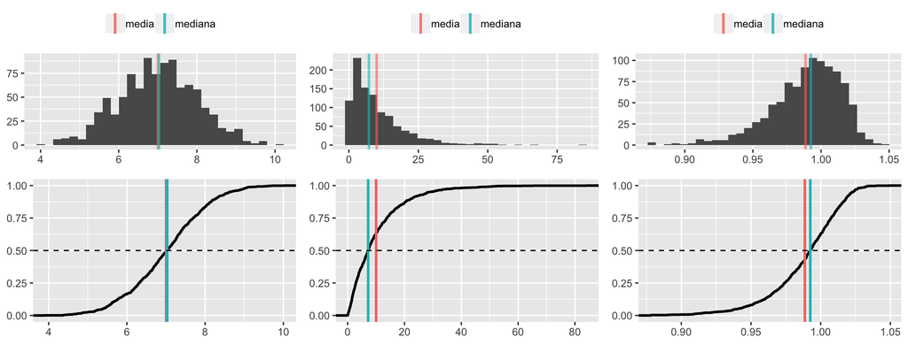

## Medida de centralidade: moda 😎

- É o valor que detém o maior número de observações
  - Ou seja, o valor ou valores mais frequentes
  - No gráfico de barras ou histograma, ele é a maior barra
  - Também é resistente a *outliers*, mas descarta muita informação

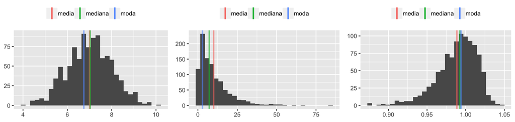

## Efeito de outliers na média

```r
df <- data.frame(x = c(1.2, 1.3, 1.5, 1.4, 1.5, 1.4, 1.5, 1.6, 1.5, 1.4, 1.5, 1.5,
                       1.6, 1.5, 1.4, 1.5, 1.6, 1.7, 1.5, 1.3, 1.4, 1.5, 1.5, 10))
df %>%
  summarise(media = mean(x), mediana = median(x), moda = names(which.max(table(x))))
```

```
##   media mediana moda
## 1 1.825     1.5  1.5
```

```r
df %>%
  filter(x < 2) %>%
  summarise(media = mean(x), mediana = median(x), moda = names(which.max(table(x))))
```

```
##      media mediana moda
## 1 1.469565     1.5  1.5
```

## Qual métrica usar?

| Tipo de variável / escala | Índice de tendência central |
| --- | --- |
| Categórica nominal | Moda |
| Categórica ordinal | Mediana |
| Contínua Simétrica e sem outliers | Média |
| Contínua Assimétrica ou com outliers | Mediana |

- Bill Gates adiciona $250 à renda média, mas nada adiciona à mediana
- Se histograma é enviesado, usar mediana. Caso contrário, usar a média

## Sumarização de dados: medidas de dispersão (ou variabilidade)

## Sumariando variabilidade

*"Então há um homem que morreu afogado atravessando um riacho com uma profundidade média de seis polegadas"*

- A tendência central não é suficiente
- Podemos adicionar à ela um índice de dispersão:
  - **Range / Intervalo** (ex: valores mínimo e máximo)
  - **Variância / Desvio padrão / Coeficiente de variação**
  - **Percentis extremos** (ex: 10-percentil e 90-percentil)
  - **Intervalo semi-quartis** (SIQR)

## Sumariando a variabilidade

- Histograma do desempenho de dois sistemas:

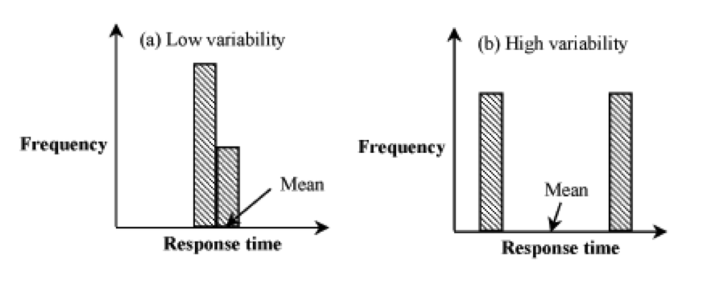

- A média é a mesma. **Mas qual você prefere?**

## Range

Intervalo: [min, max]

- Útil apenas quando os valores de uma variavél são limitados (*bounded*)
  - Dá para ter noção desses limites com o *range*
- Varia de acordo com o número de observações
  - Não dá para saber se o *range* é significativo ou não

## Variância e desvio padrão

Variância amostral (unidade dos dados ao quadrado):

\[s^2 = \frac{\sum_{i=1}^{n} (x_i - \bar{x})^2}{n - 1}\]

Desvio padrão amostral (mesma unidade dos dados):

\[s = \sqrt{s^2}\]

\[COV = \bar{C} = \frac{s}{\bar{x}}\]

## Quantis

- 0,05-quantil; 0,95-quantil: similar ao *range*
- Decis \((\frac{1}{10})\), Quartis \((\frac{1}{4})\)
- Intervalos entre quartis
  - *Inter-Quartile Range*: \[\mathit{IQR} = Q3 - Q1\]
  - *Semi IQR*: \[\mathit{SIQR} = \frac{Q3 - Q1}{2}\]

## Top frequent

- Para dados categóricos, a dispersão pode ser a porcentagem de observações das categorias mais frequentes
- Exemplo: top 90%, top 45%
  - Qual está mais espalhado?

## Como selecionar um índice de dispersão?

| Tipo de variável | Índice de dispersão |
| --- | --- |
| Categórica | Top frequent |
| Contínua Simétrica | Variância, desvio padrão ou COV |
| Contínua Assimétrica | Quantis, IQR ou SIQR |

- Intervalo (*range*) pode ser usado para complementar a análise de dispersão

## Exemplos - Índices de dispersão

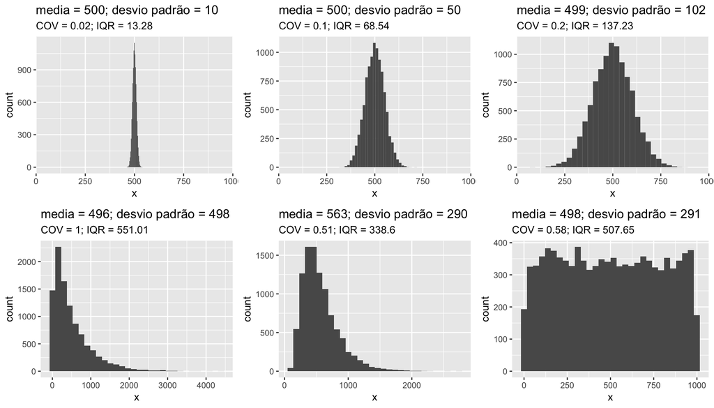

## Referências

- Slides baseados no material de:
  - Prof. Raquel Lopes (UFCG)
  - [Prof. Steven Skiena](http://www3.cs.stonybrook.edu/~skiena/data-manual/lectures/) (Stony Brok University)

Outras referências:

- [Probability and Statistics for Engineering and the Sciences](https://www.amazon.com/Probability-Statistics-Engineering-Sciences-Devore/dp/0538733527). Jay Devore
- [The Art of Computer Systems Performance Analysis](https://www.amazon.com.br/Art-Computer-Systems-Performance-Analysis/dp/0471503363). Raj Jain